# EMD539: Harmonic regression, Serfling, robust

Kayoko Shioda and Dan Weinberger

2/6/2023

## Set up

```r
# Load a dataset
us.pi <- read.csv("./Data/us_pi_mortality.csv")

us.pi$date<-as.Date(paste(us.pi$year, us.pi$modeath, '01', sep='-'))
```

## Explore the US mortality data

Today, we analyze use all-cause mortality data in the U.S. in 1980-2001. The following variables are included in the dataset:

- modeath (=month of death)
- year (=4-digit)
- date (fractional year: Year + (modeath-1)/12)
- all (=monthly number of deaths for all cause mortality)
- season (=winter season)

```r
head(us.pi)
```

```
##         date modeath year    all season
## 1 1980-01-01       1 1980 176364
## 2 1980-02-01       2 1980 173971
## 3 1980-03-01       3 1980 177360
## 4 1980-04-01       4 1980 160077
## 5 1980-05-01       5 1980 160271
## 6 1980-06-01       6 1980 154435
```

*Question:* How many months are included in this dataset? How can we quickly tell that?

```r
nrow(us.pi)

unique(us.pi$date)
```

Time series for the number of all-cause mortality: When you make a plot, it is important to pay attention to its y axis. Below, I added `ylim()` to extend y axis to zero, which is a good practice when we make plots.

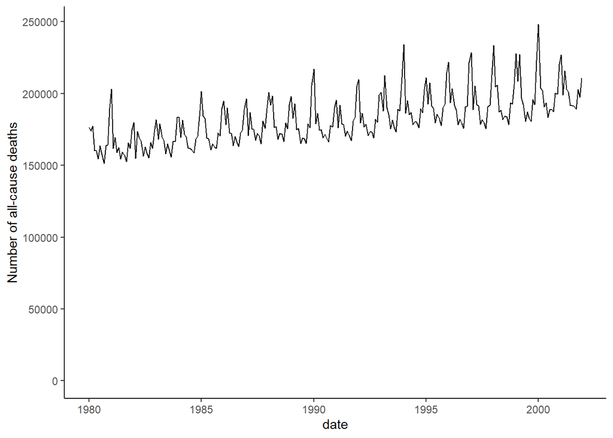

```r
p1 <- ggplot(us.pi, aes(x=date, y=all)) +
  geom_line() +
  theme_classic() +
  ylab("Number of all-cause deaths") +
  ylim(0, max(us.pi$all))

p1
```

*Question:* What do you see? Any trend in all-cause mortality?

## Today’s goal

1. Control for annual seasonality in time series by including harmonic terms (since and cosine waves).
2. Fit a serfling regression model.
3. Fit a robust regression model.

## Regression models with harmonic terms

In this section, we will fit a regression model with annual seasonality using sine & cosine waves:

$$log(Y) = \beta_0 + \beta_1 t + \beta_2
sin(\frac{2\pi t}{12}) + \beta_3 cos(\frac{2\pi t}{12})$$

where t represents time index (1, 2, …., number of data points). We will take a log of the outcome (i.e., number of all-cause deaths) in order to make the distribution look normal.

*Question* Why are denominators 12? If we were using weekly data, what would it be?

### Review: Trigonometric function

**Example 1:** Basic sine and cosine (Annual seasonality)

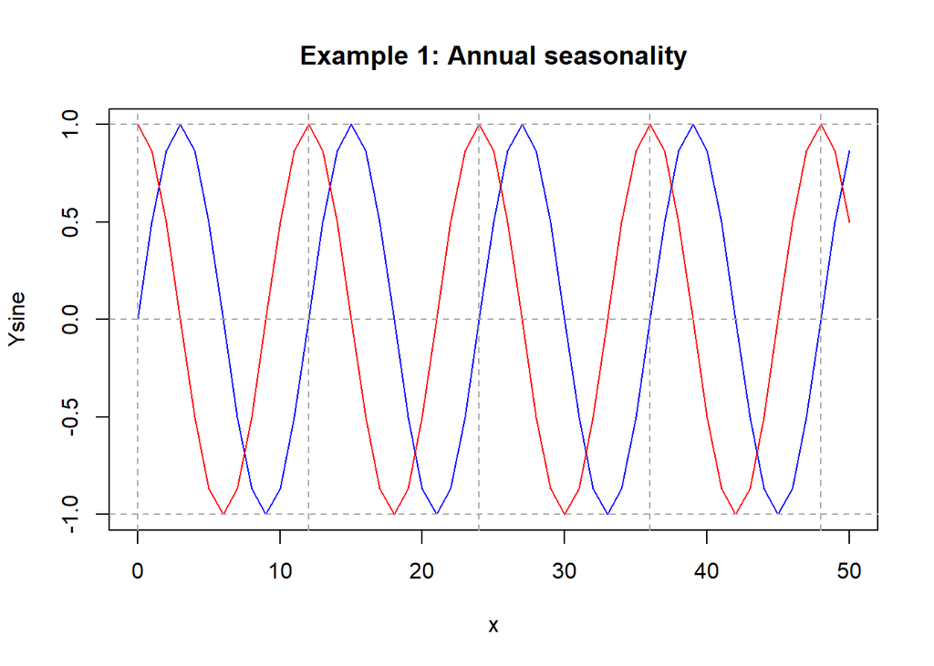

```r
# Create month index
x <- 0:50 # Month 0 to 50

# Create sine and cosine waves for annual oscillation
Ysine <- sin(2*pi*x/12) # Denominator is 12 because there are 12 months in a year
Ycos  <- cos(2*pi*x/12)

# Plot annual waves
plot(Ysine ~ x, type="l", col="blue", main="Example 1: Annual seasonality")
lines(x,Ycos,type="l",col="red")
abline(h=c(-1,0,1), lty=2, col="darkgrey")
abline(v=seq(0,50,12), lty=2, col="darkgrey")
```

**Example 2:** Variations on a sine wave

You can change the height of this sine curve and/or frequency of oscillations as follows:

[output not shown]

Shiny applications not supported in static R Markdown documents

*Question* If we want to include harmonic terms for biennial oscillation (i.e., peaks appearing every other year), what should the denominator be?

**Example 3:** Combination of sine and cosine waves

By combining sine and cosine waves, you can change the height and/or shift the phase.

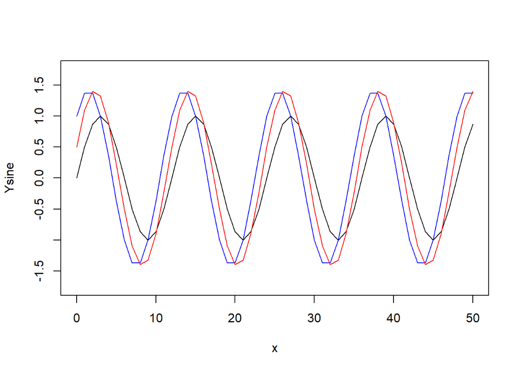

```r
x <- 0:50
Ysine <- sin(2*pi*x/12)
Combo <- sin(2*pi*x/12) + cos(2*pi*x/12)
Combo2 <- sqrt(1.75)*sin(2*pi*x/12) + 0.5*cos(2*pi*x/12)

# Plot
plot(x,  Ysine,  type="l", ylim=c(-1.75,1.75))
lines(x, Combo,  type="l", col="blue")
lines(x, Combo2, type="l", col="red")
```

## Regression models with harmonic terms

Let’s fit a regression model with annual seasonality by following the next steps.

1. Create time index variables.

```r
# Number of months in your data
n_months <- nrow(us.pi)

# Term for linear time trend
us.pi$t_1 <- seq(1, n_months)

# Term for quadratic time trend.
us.pi$t_2 <- us.pi$t_1^2
```

NOTE: Including quadratic (t_1^2), cubic (t_1^3), etc., variables gives you a more flexible curve shape.

2. Create harmonic terms for annual seasonality.

```r
# As we are using monthly data today, the denominator is 12. For weekly data, denominator would be 52 for annual seasonality.
us.pi$sin12 <- sin(2*us.pi$t_1*pi/12)
us.pi$cos12 <- cos(2*us.pi$t_1*pi/12)
```

adding in additional seasonality terms (e.g. with 6 month harmonic) allows the model to better capture the shape of teh seasonal curve. We can use model selectionc criteria to decide whether to include 24 month, or 6 or 3 monh harmonics as well. Typically the sine and cosine terms of a particular frequency go as a pair: they are both included or both excluded from the model.

```r
us.pi$sin6 <- cos(2*us.pi$t_1*pi/6)
us.pi$cos6 <- sin(2*us.pi$t_1*pi/6)

us.pi$sin3 <- cos(2*us.pi$t_1*pi/3)
us.pi$cos3 <- sin(2*us.pi$t_1*pi/3)
```

3. Fit a Poisson regression with glm(). Evaluate appropriateness of Poisson by looking at residual deviance/degrees of freedom. Ratio of these should be ~1. If >>1, use negative binomial or quasi-Poisson model.

```r
model.harmonic.pois <- glm( all ~  sin12 + cos12 + sin6+cos6+ sin3+cos3 +t_1    ,
                      na.action=na.exclude,
                      data=us.pi, family='poisson')
summary(model.harmonic.pois)
```

```
##
## Call:
## glm(formula = all ~ sin12 + cos12 + sin6 + cos6 + sin3 + cos3 +
##     t_1, family = "poisson", data = us.pi, na.action = na.exclude)
##
## Deviance Residuals:
##     Min       1Q   Median       3Q      Max
## -51.258  -10.402   -1.699    9.644   52.273
##
## Coefficients:
##              Estimate Std. Error   z value Pr(>|z|)
## (Intercept) 1.200e+01  2.973e-04 40370.078   <2e-16 ***
## sin12       4.829e-02  2.049e-04   235.637   <2e-16 ***
## cos12       5.789e-02  2.031e-04   285.089   <2e-16 ***
## sin6        1.646e-02  2.037e-04    80.800   <2e-16 ***
## cos6        1.342e-02  2.040e-04    65.780   <2e-16 ***
## sin3        1.920e-03  2.035e-04     9.433   <2e-16 ***
## cos3        2.308e-02  2.038e-04   113.225   <2e-16 ***
## t_1         8.289e-04  1.893e-06   437.757   <2e-16 ***
## ---
## Signif. codes:  0 '***' 0.001 '**' 0.01 '*' 0.05 '.' 0.1 ' ' 1
##
## (Dispersion parameter for poisson family taken to be 1)
##
##     Null deviance: 411403  on 263  degrees of freedom
## Residual deviance:  61854  on 256  degrees of freedom
## AIC: 65552
##
## Number of Fisher Scoring iterations: 3
```

3b. Fit a Negative binomial regression with annual harmonic terms using `glm.nb()`, and take a look at summary results by `summary()`

```r
model.harmonic <- glm.nb( all ~  sin12 + cos12 + sin6+cos6+ sin3+cos3 +t_1    ,
                      na.action=na.exclude,
                      data=us.pi)
summary(model.harmonic)
```

```
##
## Call:
## glm.nb(formula = all ~ sin12 + cos12 + sin6 + cos6 + sin3 + cos3 +
##     t_1, data = us.pi, na.action = na.exclude, init.theta = 809.7893311,
##     link = log)
##
## Deviance Residuals:
##     Min       1Q   Median       3Q      Max
## -3.5864  -0.7238  -0.0999   0.6209   3.2050
##
## Coefficients:
##              Estimate Std. Error  z value Pr(>|z|)
## (Intercept) 1.200e+01  4.351e-03 2758.610  < 2e-16 ***
## sin12       4.796e-02  3.067e-03   15.636  < 2e-16 ***
## cos12       5.697e-02  3.066e-03   18.583  < 2e-16 ***
## sin6        1.597e-02  3.066e-03    5.208 1.91e-07 ***
## cos6        1.328e-02  3.066e-03    4.333 1.47e-05 ***
## sin3        9.685e-04  3.066e-03    0.316    0.752
## cos3        2.167e-02  3.066e-03    7.070 1.55e-12 ***
## t_1         8.253e-04  2.847e-05   28.989  < 2e-16 ***
## ---
## Signif. codes:  0 '***' 0.001 '**' 0.01 '*' 0.05 '.' 0.1 ' ' 1
##
## (Dispersion parameter for Negative Binomial(809.7893) family taken to be 1)
##
##     Null deviance: 1786.92  on 263  degrees of freedom
## Residual deviance:  264.02  on 256  degrees of freedom
## AIC: 5395.2
##
## Number of Fisher Scoring iterations: 1
##
##
##               Theta:  809.8
##           Std. Err.:  70.8
##
##  2 x log-likelihood:  -5377.245
```

*Question:* Let’s interpret the results. Where can you find estimated coefficients for predictors?

4. Generate predicted values from the model using `add_pi()`, and plot cases and the model fit. In `predict()`, `interval` should be “prediction” instead of “confidence”, because we want to obtain 95% prediction interval (PI).

```r
# Generate prediction and prediction interval
pred_harmonic <- add_pi(us.pi, fit=model.harmonic, yhatName = "pred", alpha=0.05 )

head(pred_harmonic) # What are these numbers?
```

```
##         date modeath year    all season t_1 t_2        sin12         cos12 sin6
## 1 1980-01-01       1 1980 176364          1   1 5.000000e-01  8.660254e-01  0.5
## 2 1980-02-01       2 1980 173971          2   4 8.660254e-01  5.000000e-01 -0.5
## 3 1980-03-01       3 1980 177360          3   9 1.000000e+00  6.123032e-17 -1.0
## 4 1980-04-01       4 1980 160077          4  16 8.660254e-01 -5.000000e-01 -0.5
## 5 1980-05-01       5 1980 160271          5  25 5.000000e-01 -8.660254e-01  0.5
## 6 1980-06-01       6 1980 154435          6  36 1.224606e-16 -1.000000e+00  1.0
##            cos6 sin3          cos3     pred LPB0.025 UPB0.975
## 1  8.660254e-01 -0.5  8.660254e-01 182490.0   169770   195428
## 2  8.660254e-01 -0.5 -8.660254e-01 172555.6   159924   184994
## 3  1.224606e-16  1.0 -2.449213e-16 169054.8   157539   181223
## 4 -8.660254e-01 -0.5  8.660254e-01 165659.6   154077   177452
## 5 -8.660254e-01 -0.5 -8.660254e-01 156144.0   145124   167031
## 6 -2.449213e-16  1.0 -4.898425e-16 157543.4   146647   169117
```

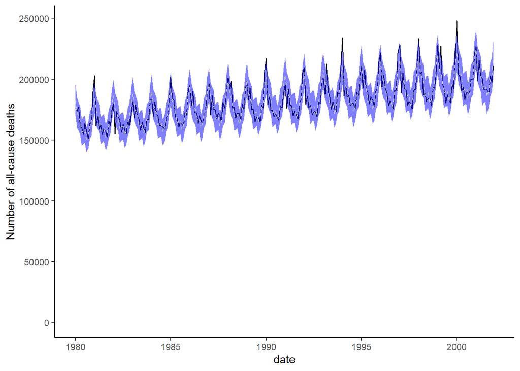

```r
# What's generated by predict()?

# Make a plot
# Add observed data

p1 +
  geom_ribbon(data=pred_harmonic,
          aes(ymin=LPB0.025,ymax=UPB0.975), fill="blue", alpha=0.5) +
  geom_line(data=pred_harmonic, aes(x=date, y=pred), col='gray', lty=2)
```

## Model comparison

Evaluate AIC scores from these 4 models and choose the most parsimonious. Typically when comparing AIC scores, smaller is better. A difference of 2 points is considered meaningful, so models that have a difference of AIC <2 are considred equivalent, and the simpler of the models would usually be selected.

```r
mod1 <- glm.nb( all ~  sin12 + cos12 + sin6+cos6+ sin3+cos3 +t_1    ,
                      na.action=na.exclude,
                      data=us.pi)

mod2 <- glm.nb( all ~  sin12 + cos12 + sin6+cos6 +t_1    ,
                      na.action=na.exclude,
                      data=us.pi)

mod3 <- glm.nb( all ~  sin12 + cos12 + sin6+cos6 +t_1    ,
                      na.action=na.exclude,
                      data=us.pi)

mod4 <-  glm.nb( all ~  sin12 + cos12 + sin6+cos6+ sin3+cos3 +t_1 + t_2   ,
                      na.action=na.exclude,
                      data=us.pi)
AIC(mod1)
```

```
## [1] 5395.245
```

```r
AIC(mod2)
```

```
## [1] 5437.069
```

```r
AIC(mod3)
```

```
## [1] 5437.069
```

```r
AIC(mod4)
```

```
## [1] 5397.094
```

## Serfling regression models

Follow the next steps to fit a serfling regression model.

1. Let’s flag winter months (that won’t be included in the baseline) using `ifelse()`.

```r
winter.months <-c(12,1,2,3)

us.pi$winter <- ifelse(us.pi$modeath %in% winter.months, 1, 0)

# Check
us.pi[1:24, c('modeath','winter')]
```

```
##    modeath winter
## 1        1      1
## 2        2      1
## 3        3      1
## 4        4      0
## 5        5      0
## 6        6      0
## 7        7      0
## 8        8      0
## 9        9      0
## 10      10      0
## 11      11      0
## 12      12      1
## 13       1      1
## 14       2      1
## 15       3      1
## 16       4      0
## 17       5      0
## 18       6      0
## 19       7      0
## 20       8      0
## 21       9      0
## 22      10      0
## 23      11      0
## 24      12      1
```

2. Create a baseline all-cause mortality variable (“bl.all”) with values for baseline months and NA for winter months.

```r
us.pi$bl.all <- ifelse(us.pi$winter==1, NA, us.pi$all)

# Check
us.pi[1:24,c('year','modeath','winter','all','bl.all')]
```

```
##    year modeath winter    all bl.all
## 1  1980       1      1 176364     NA
## 2  1980       2      1 173971     NA
## 3  1980       3      1 177360     NA
## 4  1980       4      0 160077 160077
## 5  1980       5      0 160271 160271
## 6  1980       6      0 154435 154435
## 7  1980       7      0 163698 163698
## 8  1980       8      0 157587 157587
## 9  1980       9      0 151167 151167
## 10 1980      10      0 163792 163792
## 11 1980      11      0 164181 164181
## 12 1980      12      1 189648     NA
## 13 1981       1      1 203155     NA
## 14 1981       2      1 161703     NA
## 15 1981       3      1 169316     NA
## 16 1981       4      0 158936 158936
## 17 1981       5      0 162394 162394
## 18 1981       6      0 154561 154561
## 19 1981       7      0 159150 159150
## 20 1981       8      0 156766 156766
## 21 1981       9      0 152494 152494
## 22 1981      10      0 165700 165700
## 23 1981      11      0 161873 161873
## 24 1981      12      1 174665     NA
```

3. Create the model of baseline mortality to obtain a baseline estimate.

```r
# Fit a model of baseline mortality
model.bl <- glm.nb(bl.all ~ t_1 + sin12+cos12 ,  data=us.pi)

# Summary result
summary(model.bl)
```

```
##
## Call:
## glm.nb(formula = bl.all ~ t_1 + sin12 + cos12, data = us.pi,
##     init.theta = 2131.802478, link = log)
##
## Deviance Residuals:
##      Min        1Q    Median        3Q       Max
## -2.20298  -0.77346   0.04449   0.70740   2.54791
##
## Coefficients:
##              Estimate Std. Error z value Pr(>|z|)
## (Intercept) 1.199e+01  3.630e-03 3303.28   <2e-16 ***
## t_1         7.802e-04  2.157e-05   36.17   <2e-16 ***
## sin12       3.180e-02  2.905e-03   10.95   <2e-16 ***
## cos12       3.013e-02  2.905e-03   10.37   <2e-16 ***
## ---
## Signif. codes:  0 '***' 0.001 '**' 0.01 '*' 0.05 '.' 0.1 ' ' 1
##
## (Dispersion parameter for Negative Binomial(2131.802) family taken to be 1)
##
##     Null deviance: 1639.41  on 175  degrees of freedom
## Residual deviance:  176.02  on 172  degrees of freedom
##   (88 observations deleted due to missingness)
## AIC: 3413.2
##
## Number of Fisher Scoring iterations: 1
##
##
##               Theta:  2132
##           Std. Err.:  230
##
##  2 x log-likelihood:  -3403.226
```

4. Generate predicted values.

```r
us.pi.fit<-us.pi
us.pi.fit$bl.all<-us.pi$all
serfling.ds <- add_pi(us.pi.fit, fit=model.bl, alpha=0.1 )
```

5. Create a TRUE/FALSE variable (“epi95”) that defines “epidemic months”.

Epidemic months are months where the following two conditions are met: A) Deaths are above the 95% baseline confidence limit, and B) The month is in the winter season

```r
serfling.ds$epi95 <- (serfling.ds$all > serfling.ds$UPB0.95 & serfling.ds$modeath %in% c(12,1,2,3) ) # This will create a "logical" vector (TRUE vs. FALSE)

# Check
class(serfling.ds$epi95)
```

```
## [1] "logical"
```

```r
serfling.ds[1:24,c('date','all','UPB0.95','winter','epi95')]
```

```
##          date    all UPB0.95 winter epi95
## 1  1980-01-01 176364  174042      1  TRUE
## 2  1980-02-01 173971  174668      1 FALSE
## 3  1980-03-01 177360  172572      1  TRUE
## 4  1980-04-01 160077  169647      0 FALSE
## 5  1980-05-01 160271  166225      0 FALSE
## 6  1980-06-01 154435  162742      0 FALSE
## 7  1980-07-01 163698  160891      0 FALSE
## 8  1980-08-01 157587  161174      0 FALSE
## 9  1980-09-01 151167  163291      0 FALSE
## 10 1980-10-01 163792  166214      0 FALSE
## 11 1980-11-01 164181  170336      0 FALSE
## 12 1980-12-01 189648  173774      1  TRUE
## 13 1981-01-01 203155  176352      1  TRUE
## 14 1981-02-01 161703  176285      1 FALSE
## 15 1981-03-01 169316  174356      1 FALSE
## 16 1981-04-01 158936  171461      0 FALSE
## 17 1981-05-01 162394  167459      0 FALSE
## 18 1981-06-01 154561  164395      0 FALSE
## 19 1981-07-01 159150  162598      0 FALSE
## 20 1981-08-01 156766  162701      0 FALSE
## 21 1981-09-01 152494  164305      0 FALSE
## 22 1981-10-01 165700  167776      0 FALSE
## 23 1981-11-01 161873  171460      0 FALSE
## 24 1981-12-01 174665  175527      1 FALSE
```

Now let’s take a look at a result by creating a time series plot.

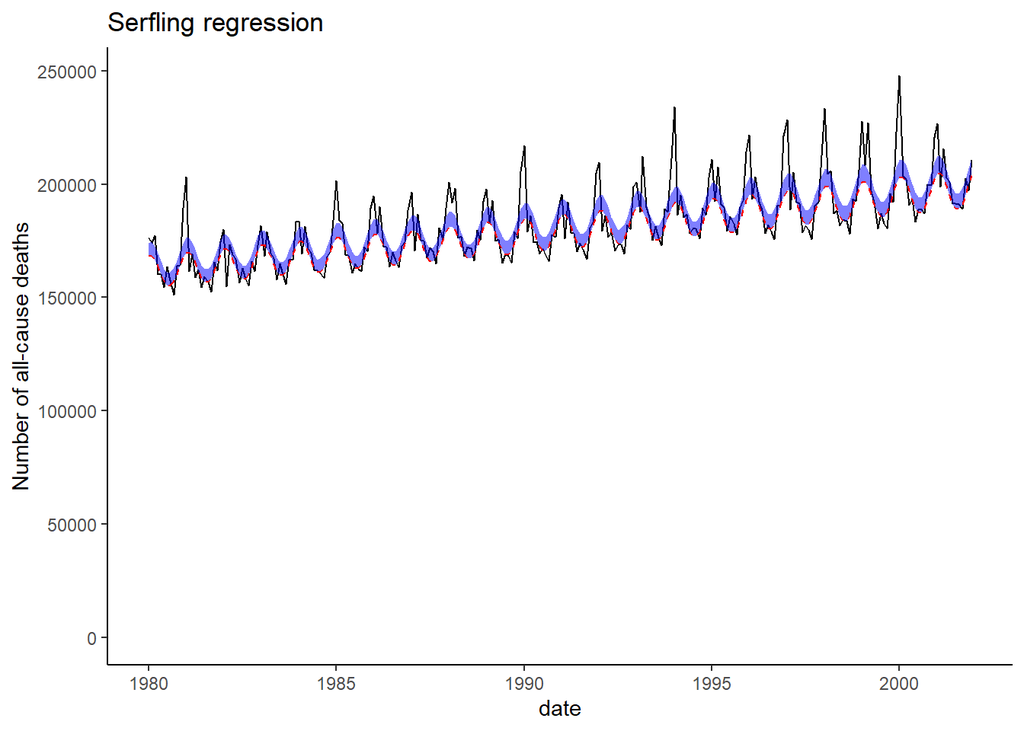

```r
p2 <- p1 +
  geom_ribbon(data=serfling.ds,
          aes(ymin=pred,ymax=UPB0.95), fill="blue", alpha=0.5) +
  geom_line(data=serfling.ds, aes(x=date, y=pred), col='red', lty=2) +
  ggtitle('Serfling regression')

p2
```

6. Calculate monthly excess deaths above the baseline during epidemic months.

```r
# Calculate excess death during epidemic months
serfling.ds$ex.all <- (serfling.ds$all - serfling.ds$pred)*(serfling.ds$epi95)

serfling.ds$ex.all2 <- (serfling.ds$all - serfling.ds$pred)*(serfling.ds$winter)

# Check
serfling.ds[1:24, c('all','pred','winter','epi95','ex.all','ex.all2')]
```

```
##       all     pred winter epi95    ex.all   ex.all2
## 1  176364 168164.2      1  TRUE  8199.843  8199.843
## 2  173971 168397.8      1 FALSE     0.000  5573.214
## 3  177360 166717.6      1  TRUE 10642.356 10642.356
## 4  160077 163654.0      0 FALSE     0.000     0.000
## 5  160271 160110.9      0 FALSE     0.000     0.000
## 6  154435 157073.1      0 FALSE     0.000     0.000
## 7  163698 155342.2      0 FALSE     0.000     0.000
## 8  157587 155369.0      0 FALSE     0.000     0.000
## 9  151167 157179.8      0 FALSE     0.000     0.000
## 10 163792 160372.3      0 FALSE     0.000     0.000
## 11 164181 164177.3      0 FALSE     0.000     0.000
## 12 189648 167613.8      1  TRUE 22034.207 22034.207
## 13 203155 169746.1      1  TRUE 33408.946 33408.946
## 14 161703 169981.9      1 FALSE     0.000 -8278.880
## 15 169316 168285.9      1 FALSE     0.000  1030.067
## 16 158936 165193.5      0 FALSE     0.000     0.000
## 17 162394 161617.0      0 FALSE     0.000     0.000
## 18 154561 158550.7      0 FALSE     0.000     0.000
## 19 159150 156803.5      0 FALSE     0.000     0.000
## 20 156766 156830.5      0 FALSE     0.000     0.000
## 21 152494 158658.4      0 FALSE     0.000     0.000
## 22 165700 161880.9      0 FALSE     0.000     0.000
## 23 161873 165721.7      0 FALSE     0.000     0.000
## 24 174665 169190.5      1 FALSE     0.000  5474.488
```

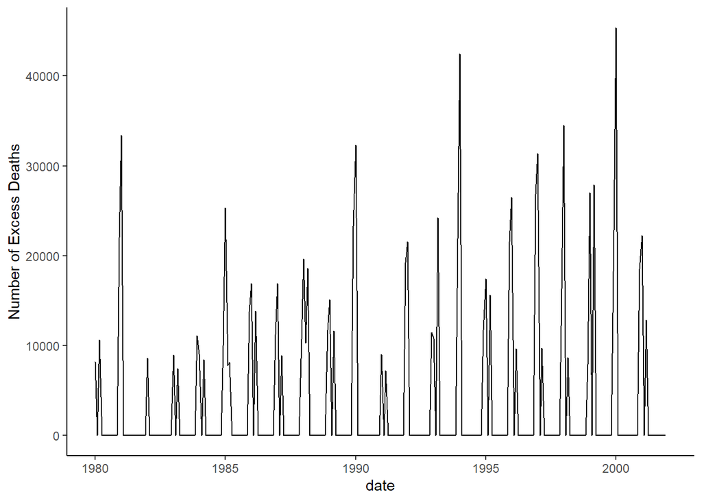

```r
# Plot
p3.excess <- ggplot(serfling.ds, aes(x=date, y=ex.all)) +
  geom_line() +
  theme_classic() +
  ylab('Number of Excess Deaths')
p3.excess
```

7. Sum all excess deaths during epidemic months to obtain seasonal excess deaths.

We will round off to the nearest hundred. You should avoid presenting false precision in your summaries

```r
excessN_serfling <- serfling.ds[serfling.ds$season!='',] %>%
  group_by(season) %>%
  summarize('Excess_deaths_serfling'=round(sum(ex.all),-2),'Excess_deaths_serfling_incl_negatives'=round(sum(ex.all2),-2),'N_epidemic_months'=sum(epi95))

head(excessN_serfling)
```

```
## # A tibble: 6 x 4
##   season    Excess_deaths_serfling Excess_deaths_serfling_incl_negatives N_epi~1
##   <chr>                      <dbl>                                 <dbl>   <int>
## 1 1980/1981                  55400                                 48200       2
## 2 1981/1982                   8600                                   800       1
## 3 1982/1983                  16400                                 13500       2
## 4 1983/1984                  28600                                 23100       3
## 5 1984/1985                  51300                                 51300       4
## 6 1985/1986                  44600                                 44900       3
## # ... with abbreviated variable name 1: N_epidemic_months
```

```r
htmlTable::htmlTable(excessN_serfling)
```

|  | season | Excess_deaths_serfling | Excess_deaths_serfling_incl_negatives | N_epidemic_months |
| --- | --- | --- | --- | --- |
| 1 | 1980/1981 | 55400 | 48200 | 2 |
| 2 | 1981/1982 | 8600 | 800 | 1 |
| 3 | 1982/1983 | 16400 | 13500 | 2 |
| 4 | 1983/1984 | 28600 | 23100 | 3 |
| 5 | 1984/1985 | 51300 | 51300 | 4 |
| 6 | 1985/1986 | 44600 | 44900 | 3 |
| 7 | 1986/1987 | 37000 | 27800 | 3 |
| 8 | 1987/1988 | 59200 | 59200 | 4 |
| 9 | 1988/1989 | 38500 | 37900 | 3 |
| 10 | 1989/1990 | 55600 | 52800 | 2 |
| 11 | 1990/1991 | 16200 | 11400 | 2 |
| 12 | 1991/1992 | 40800 | 31500 | 2 |
| 13 | 1992/1993 | 46500 | 44300 | 3 |
| 14 | 1993/1994 | 64400 | 63900 | 2 |
| 15 | 1994/1995 | 44800 | 43600 | 3 |
| 16 | 1995/1996 | 57700 | 55600 | 3 |
| 17 | 1996/1997 | 67900 | 59200 | 3 |
| 18 | 1997/1998 | 59500 | 64900 | 3 |
| 19 | 1998/1999 | 62800 | 70000 | 3 |
| 20 | 1999/2000 | 68200 | 69800 | 2 |
| 21 | 2000/2001 | 53600 | 47600 | 3 |

```r
# You can also export the excess.table data into .csv file if needed
write.csv(excessN_serfling,"./outputs/summary_excess_mortality_1980_2001.csv")
```

## Robust regression

Follow the next steps to fit a robust regression model.

1. Load a required package.

```r
require(MASS)
```

2. Fit a robust regression using `rlm()`.

```r
rr <- rlm(log(all) ~ t_1 +  sin12 + cos12  , data =us.pi)
```

3. Generate predicted values.

```r
# Generate prediction (Use 90% PI instead of 95% PI)
pred.rr.robust <- exp(predict(rr, us.pi, se.fit=TRUE, interval="prediction", level=0.90)[[1]])
```

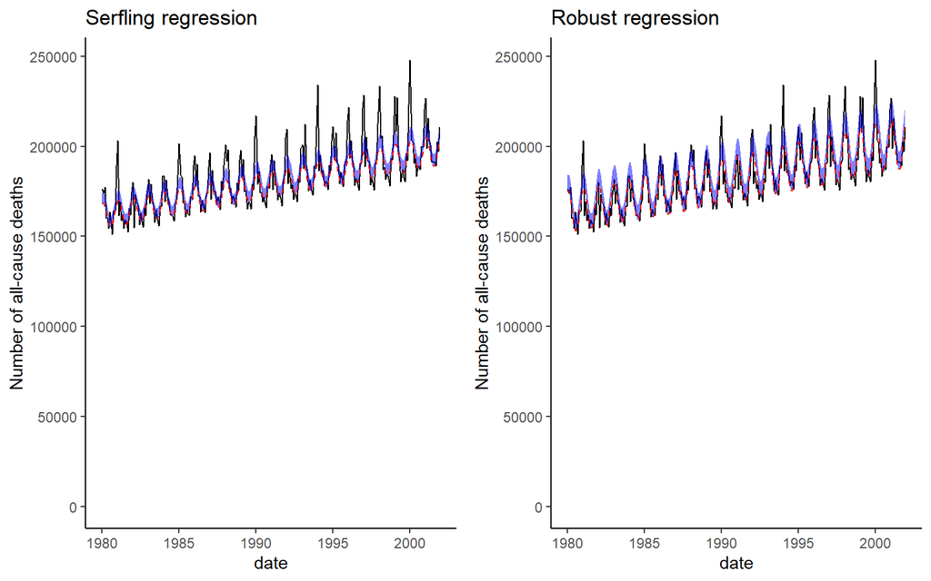

```r
pred.rr.robust <- cbind.data.frame(us.pi, pred.rr.robust)

p3 <- p1 +
 geom_ribbon(data=pred.rr.robust,
          aes(ymin=fit,ymax=upr), fill="blue", alpha=0.5) +
  geom_line(data=pred.rr.robust, aes(x=date, y=fit), col='red', lty=2) +
  ggtitle('Robust regression')

gridExtra::grid.arrange(p2, p3, ncol=2)
```

4. Create a TRUE/FALSE variable that defines epidemic months (i.e., Deaths are above the **90%** baseline confidence limit and the month is in the winter season.)

```r
epi.rr <- (us.pi$all > pred.rr.robust$upr & us.pi$winter==1)
```

5. Calculate excess deaths per month.

```r
pred.rr.robust$excessN <- (us.pi$all - pred.rr.robust$fit)
```

```r
# Sums excess mortality over each epidemic season (which includes 2 years)

excessN_robust <- pred.rr.robust[pred.rr.robust$season!='',] %>%
  group_by(season) %>%
  summarize('Excess_deaths_robust'=round(sum(excessN),-2))

head(excessN_robust)
```

```
## # A tibble: 6 x 2
##   season    Excess_deaths_robust
##   <chr>                    <dbl>
## 1 1980/1981                14500
## 2 1981/1982               -24700
## 3 1982/1983               -13500
## 4 1983/1984                -4000
## 5 1984/1985                19400
## 6 1985/1986                14600
```

```r
htmlTable::htmlTable(excessN_robust)
```

|  | season | Excess_deaths_robust |
| --- | --- | --- |
| 1 | 1980/1981 | 14500 |
| 2 | 1981/1982 | -24700 |
| 3 | 1982/1983 | -13500 |
| 4 | 1983/1984 | -4000 |
| 5 | 1984/1985 | 19400 |
| 6 | 1985/1986 | 14600 |
| 7 | 1986/1987 | -1800 |
| 8 | 1987/1988 | 28500 |
| 9 | 1988/1989 | 3500 |
| 10 | 1989/1990 | 15700 |
| 11 | 1990/1991 | -23500 |
| 12 | 1991/1992 | -7600 |
| 13 | 1992/1993 | 16000 |
| 14 | 1993/1994 | 28700 |
| 15 | 1994/1995 | 12000 |
| 16 | 1995/1996 | 22500 |
| 17 | 1996/1997 | 23900 |
| 18 | 1997/1998 | 22100 |
| 19 | 1998/1999 | 34600 |
| 20 | 1999/2000 | 25800 |
| 21 | 2000/2001 | 13400 |

```r
# You can also export the excess.table data into .csv file if needed
write.csv(excessN_robust,"./outputs/summary_excess_mortality_robust_1980_2001.csv")
```

## Compare serfling and robust regression estimates for exess cases

```r
comp1 <- merge(excessN_robust, excessN_serfling, by='season')

htmlTable::htmlTable((comp1))
```

|  | season | Excess_deaths_robust | Excess_deaths_serfling | Excess_deaths_serfling_incl_negatives | N_epidemic_months |
| --- | --- | --- | --- | --- | --- |
| 1 | 1980/1981 | 14500 | 55400 | 48200 | 2 |
| 2 | 1981/1982 | -24700 | 8600 | 800 | 1 |
| 3 | 1982/1983 | -13500 | 16400 | 13500 | 2 |
| 4 | 1983/1984 | -4000 | 28600 | 23100 | 3 |
| 5 | 1984/1985 | 19400 | 51300 | 51300 | 4 |
| 6 | 1985/1986 | 14600 | 44600 | 44900 | 3 |
| 7 | 1986/1987 | -1800 | 37000 | 27800 | 3 |
| 8 | 1987/1988 | 28500 | 59200 | 59200 | 4 |
| 9 | 1988/1989 | 3500 | 38500 | 37900 | 3 |
| 10 | 1989/1990 | 15700 | 55600 | 52800 | 2 |
| 11 | 1990/1991 | -23500 | 16200 | 11400 | 2 |
| 12 | 1991/1992 | -7600 | 40800 | 31500 | 2 |
| 13 | 1992/1993 | 16000 | 46500 | 44300 | 3 |
| 14 | 1993/1994 | 28700 | 64400 | 63900 | 2 |
| 15 | 1994/1995 | 12000 | 44800 | 43600 | 3 |
| 16 | 1995/1996 | 22500 | 57700 | 55600 | 3 |
| 17 | 1996/1997 | 23900 | 67900 | 59200 | 3 |
| 18 | 1997/1998 | 22100 | 59500 | 64900 | 3 |
| 19 | 1998/1999 | 34600 | 62800 | 70000 | 3 |
| 20 | 1999/2000 | 25800 | 68200 | 69800 | 2 |
| 21 | 2000/2001 | 13400 | 53600 | 47600 | 3 |

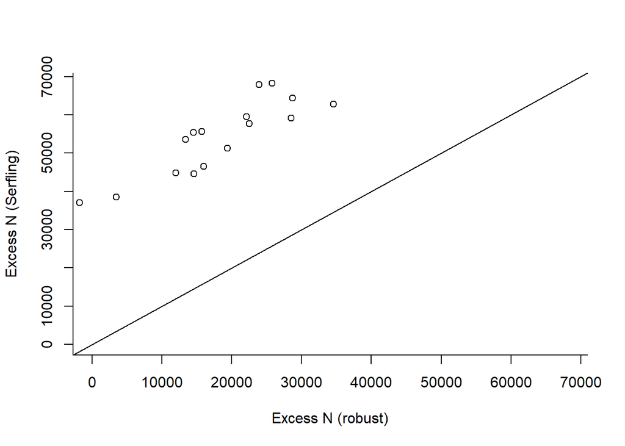

```r
plot(comp1$Excess_deaths_robust, comp1$Excess_deaths_serfling,
     xlab='Excess N (robust)',
     ylab='Excess N (Serfling)' ,
     bty='l',
     xlim=c(0, max(comp1$Excess_deaths_serfling)),
     ylim=c(0, max(comp1$Excess_deaths_serfling)))
abline(a=0, b=1)
```

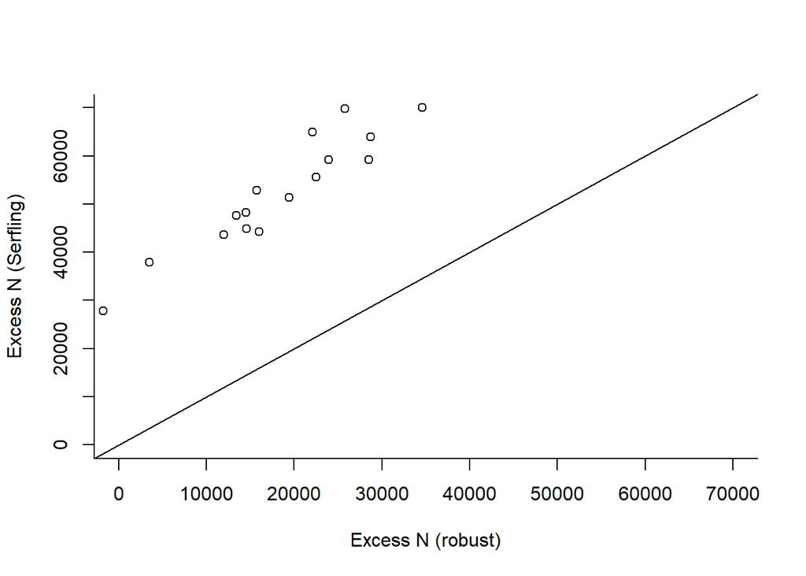

```r
plot(comp1$Excess_deaths_robust, comp1$Excess_deaths_serfling_incl_negatives,
     xlab='Excess N (robust)',
     ylab='Excess N (Serfling)' ,
     bty='l',
     xlim=c(min(c(0,min(comp1$Excess_deaths_serfling_incl_negatives))), max(comp1$Excess_deaths_serfling_incl_negatives)),
     ylim=c(0, max(comp1$Excess_deaths_serfling_incl_negatives)))
abline(a=0, b=1)
```

## Summary

These examples show us how to fit seasonal regressions to all cause mortality data from the US. We use harmonics to adjust for seasonality and polynomials to adjust for underlying long-term trends. In this exmaple, the analysis is done retrospectively to evaluate the burden of spikes in disease in the winter months (due to influenza or other respiratory pathogens). To prevent previous epidemics from skewing our baselinemwe can either fit a robust regression fit to all of the data, or we can fit a Serfing regression, where we exclude certain months where we expect to have epidemics and interpolate the missing months. We also fit a negative binomial regression where we included all of the months (rather than excluding the winter mnths, as in Serfling regression) In some instances, the 3 approaches will give very similar baselines. If there is a strong epidemic in the historic period, this could skew the baselines.

As with other approaches (e.g. historical limits, Farrington), we can adjust the stringency of the epidemic threshold by modifying the width of the predictions intervals (fiddle with alpha).

In these examples, the analyses are performed retrospectively. In reality, the same approach can be applied prospectively, fitting the model to available data and performing 1 step ahead prediction. The model could be refit as more data become available or at some specified interval (e.g. quarterly)